# Neighbor2Neighbor Program Evlauation

### 3. Model-predicted voting rates

Finally, we can get a measure of predicted probability of voting in these two groups:

[output not shown]

```
## Model contains splines or polynomial terms. Consider using
##   `terms="canvass_result2 [all]"` to get smooth plots. See also
##   package-vignette 'Adjusted Predictions at Specific Values'.
```

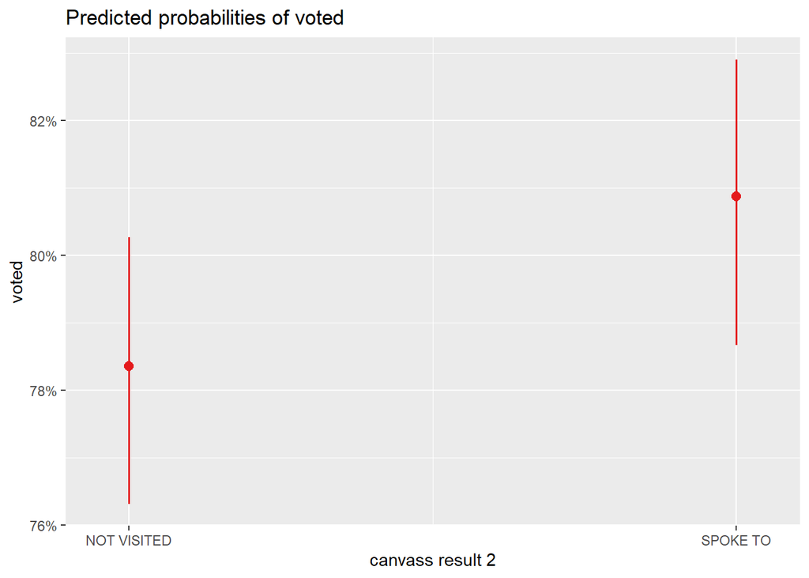

```r
plot_model(m2, type = "pred", terms = "canvass_result2")
```

Overall, we’re seeing about a 2.5 percentage point increase in voting for voters that were successfully contacted vs those that were in the control group.

A few more results of interest: First, the association between (z-transformed) age on predicted probability of voting:

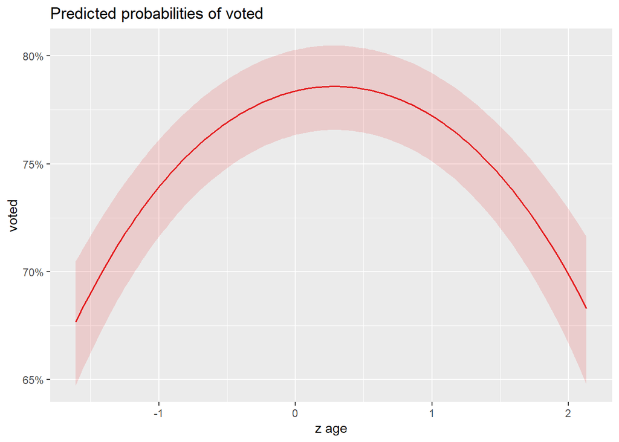

```r
plot_model(m2, type = "pred", terms = "z_age [all]")
```

And, surprisingly, the *negative* association between total assignments a volunteer took on and their contacts’ probability of voting:

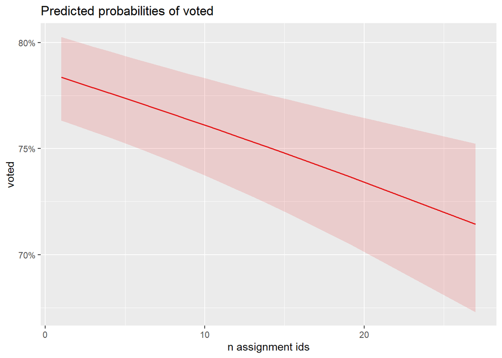

```r
plot_model(m2, type = "pred", terms = "n_assignment_ids [all]")
```

Finally, we can see the predicted probabilities of voting by race. Note that `race == "UNK"` voters are here predicted to vote at the *highest* rate. This discrepancy between model predictions and raw data is addressed in the `analysis.R` file.

```
## Model contains splines or polynomial terms. Consider using `terms="race2
##   [all]"` to get smooth plots. See also package-vignette 'Adjusted
##   Predictions at Specific Values'.
```

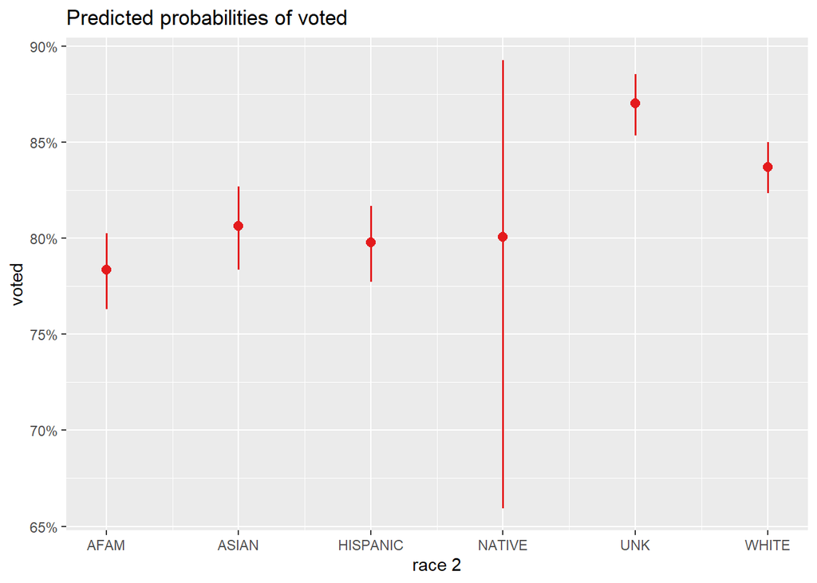

```r
plot_model(m2, type = "pred", terms = "race2")
```